# Las bases de los pronósticos

Pablo Benavides-Herrera

2020-04-06

[figure not shown]

[figure not shown]

[figure not shown]

Las paqueterías a usar en este documento:

```r
library("easypackages")
packages("tidyverse","fpp3", "tsibble", "feasts","fable")
```

# Un flujo de trabajo limpio de pronóstico

El flujo de trabajo, cuando se va a realizar un proceso, se puede dividir en pasos.

1. Preparación de los datos (limpieza)
2. Gráfica de los datos (visualización)
3. Definición del modelo (especificación)
4. Entrenamiento del modelo (estimación)
5. Revisar el desempeño del modelo (evaluación)
6. Producir pronósticos

## 1. Preparación de los datos (limpieza)

Esto siempre es lo primero que se hace y puede ir desde simplemente cargar los datos en **R**, hasta limpiezas más detalladas, como identificar valores omitidos, `NA`, filtrado de la serie, etc. Para esto, utilizamos varias funciones de las paqueterías `tsibble` y `tidyverse`, que simplifican mucho estas tareas.

## 2. Gráfica de los datos (visualización)

Continuaremos trabajando con los datos de `global_economy` para ejemplificar esto.

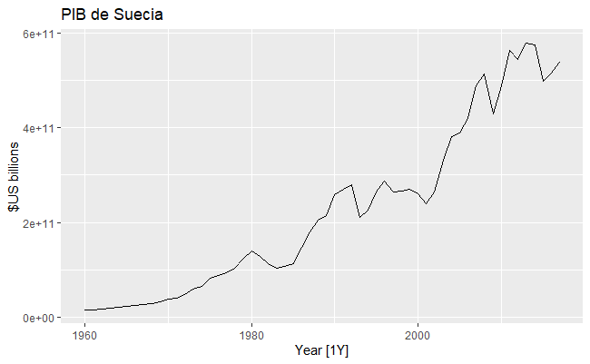

```r
global_economy %>%
  filter(Country == "Sweden") %>%
  autoplot(GDP) +
    ggtitle("PIB de Suecia") + ylab("$US billions")
```

## 3. Definición del modelo (especificación)

Antes de ajustar un modelo a los datos, se debe **describir** el modelo. Existen muchos tipos de modelos de pronóstico distintos, y es muy importante que escojamos el más apropiado, para obtener buenos pronósticos.

Los modelos en **R**, como vimos con la regresión lineal (`lm(y ~ x1 + x2 + ... + xn)`), se especifican en formato de fórmula ( `y ~ x`), siendo la `y` la variable dependiente (o variable a explicar), y la o las `x` las variables independientes (o variables explicativas, regresoras, etc.).

Podemos tomar, p. ej., un modelo lineal de series de tiempo, `TSLM`, modela los datos que se le incluyan mediante una tendencia lineal.

```r
TSLM(GDP  ~ trend())
```

## 4. Entrenamiento del modelo (estimación)

Una vez que se especificó el modelo, lo que sigue es entrenar al modelo.

Entrenar un modelo significa pasarle los datos para que, estadísticamente, encuentre los parámetros que realizan el mejor ajuste posible.

Siguiendo con el ejemplo del modelo lineal:

```r
fit <- global_economy %>%
  model(Modelo_tendencia = TSLM(GDP ~ trend()))
```

Con esto se ajustó un modelo lineal y el objeto resultante es un `mable` (model table).

```r
fit
```

```
# A mable: 263 x 2
# Key:     Country [263]
   Country             Modelo_tendencia
   <fct>                        <model>
 1 Afghanistan                   <TSLM>
 2 Albania                       <TSLM>
 3 Algeria                       <TSLM>
 4 American Samoa                <TSLM>
 5 Andorra                       <TSLM>
 6 Angola                        <TSLM>
 7 Antigua and Barbuda           <TSLM>
 8 Arab World                    <TSLM>
 9 Argentina                     <TSLM>
10 Armenia                       <TSLM>
# ... with 253 more rows
```

## 5. Revisar el desempeño del modelo (evaluación)

Ya teniendo el modelo entrenado, debemos revisar el *performance* en los datos reales. Esto es, ¿qué tan bien se ajusta el modelo a los datos?, en caso de estar indecisos entre varios modelos, ¿cuál escogemos como el mejor y por qué?

## 6. Producir pronósticos

Cuando ya evaluamos que el modelo ajustado se encuentra dentro de los parámetros deseados, podemos proceder a realizar los pronósticos. En .**R**, podemos usar el comando `forecast()`, en el cual debemos especificar el número de periodos a pronosticar. Por ejemplo, par pronosticar los siguientes 12 meses, escribiríamos `h = 12`. También podemos usar lenguaje ordinario (en inglés), `h = "1 year"`.

```r
fcst <- fit %>% forecast(h = "3 years")
fcst
```

```
# A fable: 789 x 5 [1Y]
# Key:     Country, .model [263]
   Country    .model      Year                 GDP     .mean
   <fct>      <chr>      <dbl>              <dist>     <dbl>
 1 Afghanist~ Modelo_te~  2018 N(1.6e+10, 1.3e+19)   1.62e10
 2 Afghanist~ Modelo_te~  2019 N(1.7e+10, 1.3e+19)   1.65e10
 3 Afghanist~ Modelo_te~  2020 N(1.7e+10, 1.3e+19)   1.68e10
 4 Albania    Modelo_te~  2018 N(1.4e+10, 3.9e+18)   1.37e10
 5 Albania    Modelo_te~  2019 N(1.4e+10, 3.9e+18)   1.42e10
 6 Albania    Modelo_te~  2020 N(1.5e+10, 3.9e+18)   1.46e10
 7 Algeria    Modelo_te~  2018 N(1.6e+11, 9.4e+20)   1.58e11
 8 Algeria    Modelo_te~  2019 N(1.6e+11, 9.4e+20)   1.61e11
 9 Algeria    Modelo_te~  2020 N(1.6e+11, 9.4e+20)   1.64e11
10 American ~ Modelo_te~  2018 N(6.8e+08, 1.7e+15)   6.82e 8
# ... with 779 more rows
```

El resultado es una `fable` (forecasting table) o tabla de pronósticos. El pronóstico se puede graficar fácilmente junto con los datos reales, usando `autoplot()`.

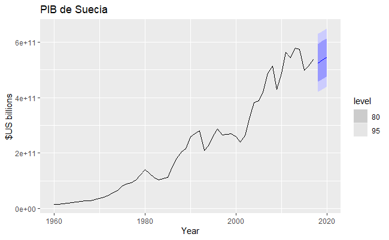

```r
fcst %>%
  filter(Country=="Sweden") %>%
  autoplot(global_economy) +
    ggtitle("PIB de Suecia") + ylab("$US billions")
```

# Métodos sencillos de pronóstico

Utilizaremos de *benchmark* a lo largo del curso estos métodos básicos de pronóstico. En ocasiones, a pesar de su sencillez, pueden llegar a ser muy útiles.

Utilizaremos los datos de producción de ladrillos para esta sección.

```r
bricks <- aus_production %>% filter_index("1970" ~ "2004")
```

## Método del promedio (media)

En este pronóstico, las predicciones de todos los valores futuros son la media de los datos históricos.

$$\hat{y}_{T+h | T}=\bar{y}=\left(y_{1}+\cdots+y_{T}\right) / T$$

```r
bricks %>% model(MEAN(Bricks))
```

| MEAN(Bricks) |
| --- |

## Método ingenuo (Naïve method)

Aquí, lo que se hace es que se toma el último valor como el pronóstico para todos los valores futuros.

$$\hat{y}_{T+h | T}=y_{T}$$
Dado que un pronóstico ingenuo es óptimo cuando se tienen datos que siguen una *caminata aleatoria*, a estos pronósticos se les conoce como **pronósticos de caminata aleatoria**.

```r
bricks %>% model(NAIVE(Bricks))
```

| NAIVE(Bricks) |
| --- |

## Método ingenuo estacional (seasonal Naïve)

Un método similar es el ingenuo estacional. Lo que cambia con el anterior es que se agrega un componente para lidiar con datos altamente estacionales.

$$\hat{y}_{T+h | T}=y_{T+h-m(k+1)}$$

```r
bricks %>% model(SNAIVE(Bricks))
```

| SNAIVE(Bricks) |
| --- |

## Método del drift (deriva)

Este método es una variación del método ingenuo, que permite que el pronóstico aumente o disminuya en el tiempo. El aumento del cambio es el cambio promedio en los datos históricos.

$$\hat{y}_{T+h | T}=y_{T}+\frac{h}{T-1} \sum_{t=2}^{T}\left(y_{t}-y_{t-1}\right)=y_{T}+h\left(\frac{y_{T}-y_{1}}{T-1}\right)$$

```r
bricks %>% model(RW(Bricks ~ drift()))
```

| RW(Bricks ~ drift()) |
| --- |

Esto es lo mismo que trazar una línea recta que conecte el primer y último punto en los datos históricos y continuar la recta hacia adelante.

```
Plot variable not specified, automatically selected `.vars = Beer`
```

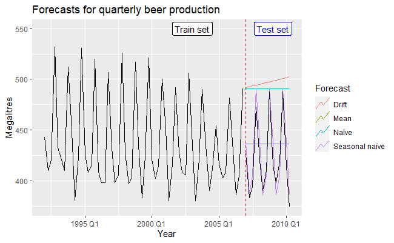

```r
# Set training data from 1992 to 2006
train <- aus_production %>% filter_index("1992 Q1" ~ "2006 Q4")
# Fit the models
beer_fit <- train %>%
  model(
    Mean = MEAN(Beer),
    `Naïve` = NAIVE(Beer),
    `Seasonal naïve` = SNAIVE(Beer),
    Drift = RW(Beer ~ drift())
  )
# Generate forecasts for 14 quarters
beer_fc <- beer_fit %>% forecast(h=14)

# Plot forecasts against actual values
beer_fc %>%
  autoplot(train, level = NULL) +
  autolayer(filter_index(aus_production, "2007 Q1" ~ .),
            color = "black") +
  ggtitle("Forecasts for quarterly beer production") +
  xlab("Year") + ylab("Megalitres") +
  guides(colour=guide_legend(title="Forecast")) +
  geom_vline(xintercept = as.Date("2007-01-01"), color = "firebrick",
             linetype = "dashed") +
  annotate("label", x = c(as.Date("2003-01-01"),as.Date("2009-01-01")),
           y = 550, label = c("Train set", "Test set"),
           color = c("black","blue"))
```

```
Plot variable not specified, automatically selected `.vars = Beer`
```

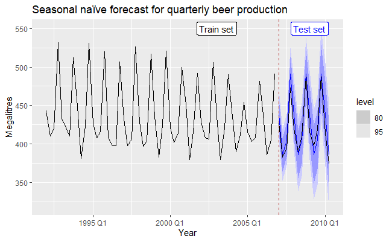

```r
beer_fc %>%
  filter(.model == "Seasonal naïve") %>%
  autoplot(train) +
  autolayer(filter_index(aus_production, "2007 Q1" ~ .),
            color = "black") +
  ggtitle("Seasonal naïve forecast for quarterly beer production") +
  xlab("Year") + ylab("Megalitres") +
  guides(colour=guide_legend(title="Forecast")) +
  geom_vline(xintercept = as.Date("2007-01-01"), color = "firebrick",
             linetype = "dashed") +
  annotate("label", x = c(as.Date("2003-01-01"),as.Date("2009-01-01")),
           y = 550, label = c("Train set", "Test set"),
           color = c("black","blue"))
```

Otro ejemplo:

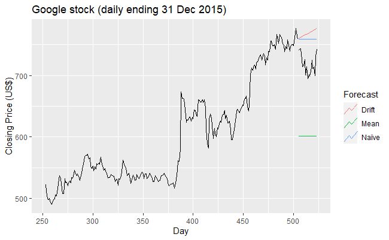

```r
# Re-index based on trading days
google_stock <- gafa_stock %>%
  filter(Symbol == "GOOG") %>%
  mutate(day = row_number()) %>%
  update_tsibble(index = day, regular = TRUE)
# Filter the year of interest
google_2015 <- google_stock %>% filter(year(Date) == 2015)
# Fit the models
google_fit <- google_2015 %>%
  model(
    Mean = MEAN(Close),
    `Naïve` = NAIVE(Close),
    Drift = NAIVE(Close ~ drift())
  )
# Produce forecasts for the 19 trading days in January 2015
google_fc <- google_fit %>% forecast(h = 19)
# A better way using a tsibble to determine the forecast horizons
google_jan_2016 <- google_stock %>%
  filter(yearmonth(Date) == yearmonth("2016 Jan"))
google_fc <- google_fit %>% forecast(google_jan_2016)
# Plot the forecasts
google_fc %>%
  autoplot(google_2015, level = NULL) +
    autolayer(google_jan_2016, Close, color='black') +
    ggtitle("Google stock (daily ending 31 Dec 2015)") +
    xlab("Day") + ylab("Closing Price (US$)") +
    guides(colour=guide_legend(title="Forecast"))
```

# Valores ajustados *(fitted)* y residuales

Cada observación en una serie de tiempo puede ser pronosticada utilizando los datos históricos previos. A estos se les conoce como valores ajustados (o *fitted*), $\hat{y}_t$.

Los residuales en un modelo de series de tiempo es la información que el modelo no logró capturar. Esto es, es la diferencia entre los valores reales y los valores ajustados.

$$e_{t}=y_{t}-\hat{y}_{t}$$

```r
augment(beer_fit)
```

| .model | Quarter | Beer | .fitted | .resid |
| --- | --- | --- | --- | --- |
| Mean | 1992 Q1 | 443 | 436.4500 | 6.5500000 |
| Mean | 1992 Q2 | 410 | 436.4500 | -26.4500000 |
| Mean | 1992 Q3 | 420 | 436.4500 | -16.4500000 |
| Mean | 1992 Q4 | 532 | 436.4500 | 95.5500000 |
| Mean | 1993 Q1 | 433 | 436.4500 | -3.4500000 |
| Mean | 1993 Q2 | 421 | 436.4500 | -15.4500000 |
| Mean | 1993 Q3 | 410 | 436.4500 | -26.4500000 |
| Mean | 1993 Q4 | 512 | 436.4500 | 75.5500000 |
| Mean | 1994 Q1 | 449 | 436.4500 | 12.5500000 |
| Mean | 1994 Q2 | 381 | 436.4500 | -55.4500000 |

[output cut: 230 more lines]

Es muy importante analizar los residuos para determinar si nuestros modelos están bien ajustados. Si logramos detectar patrones en los residuales, puede ser indicio de que el modelo puede mejorarse.

# Diagnóstico de residuales

Un buen modelo de pronóstico va a producir residuales con las siguientes características:

1. **No están autocorrelacionados**. Si se detectan correlaciones entre residuos, todavía hay información útil que se debe modelar.
2. **La media de los residuos es cero**. Si la media es distinta de cero, entonces el pronóstico está sesgado.

**Nota:** El hecho de que un pronóstico cumpla esto, no quiere decir que sea el mejor pronóstico que podamos hacer. Próximamente revisaremos qué otras medidas podemos evaluar para determinar cuál es el mejor pronóstico.

Existen dos características adicionales que son útiles, mas no necesarias, para los residuos de un pronóstico:

3. Los residuos tienen una varianza constante.
4. Los residuos se distribuyen de manera normal.

Las transformaciones de Box-Cox pueden ayudar, en algunos casos a lograr cumplir estas características.

Continuemos con el ejemplo del pronóstico del precio de la acción de Google. En muchas ocasiones, el mejor pronóstico para los precios de mercados bursátiles e índices suele ser el realiado mediante el método Naïve.

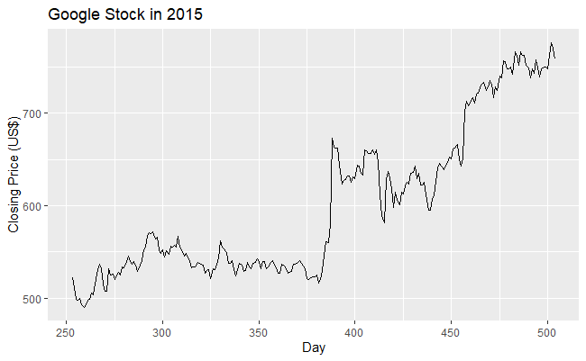

```r
google_2015 %>% autoplot(Close) +
  xlab("Day") + ylab("Closing Price (US$)") +
  ggtitle("Google Stock in 2015")
```

Aplicaremos solo el método Naïve para pronosticar el precio futuro de la acción de Google.

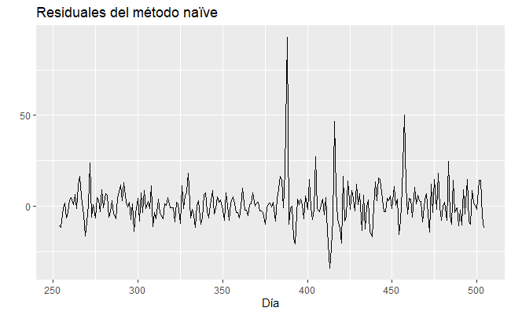

```r
aug <- google_2015 %>% model(NAIVE(Close)) %>% augment()
aug %>% autoplot(.resid) + xlab("Día") + ylab("") +
  ggtitle("Residuales del método naïve")
```

De la gráfica de los residuales podemos observar que la media parece estar muy cercana al cero y que la variación parece invariante en el tiempo, a excepción de un outlier.

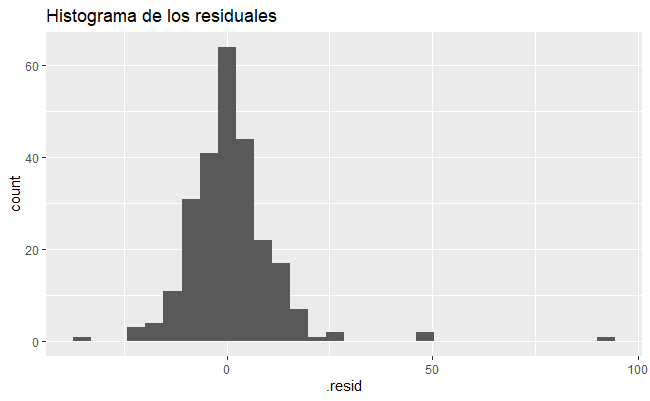

```r
aug %>%
  ggplot(aes(x = .resid)) +
  geom_histogram() +
  ggtitle("Histograma de los residuales")
```

Del histograma, podemos ver que los residuales parecen distribuirse como una normal, pero con una cola más grande.

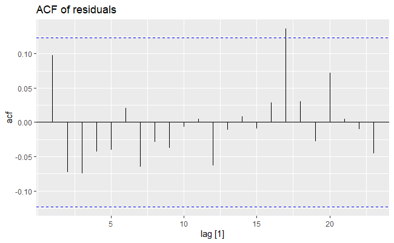

```r
aug %>% ACF(.resid) %>% autoplot() + ggtitle("ACF of residuals")
```

Así, el método naïve parece generar pronósticos que capturan toda la información relevante de la serie y, por lo tanto, que satisfacen todas las características necesarias. Por consecuencia, los pronósticos derivados de este método pueden ser bastante buenos, pero los intervalos de predicción pudieran ser imprecisos.

Podemos obtener estas mismas gráficas con un solo comando, `gg_tsresiduals()`.

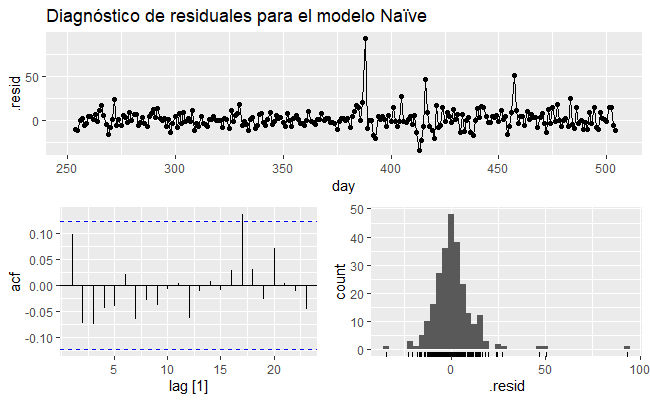

```r
google_2015 %>%
  model(NAIVE(Close)) %>%
  gg_tsresiduals() +
  ggtitle("Diagnóstico de residuales para el modelo Naïve")
```

Como vimos antes, el método Naïve es óptimo para este tipo de series. ¿Qué hubiera sucedido si ajustáramos otro modelo? Probemos con el método de la media:

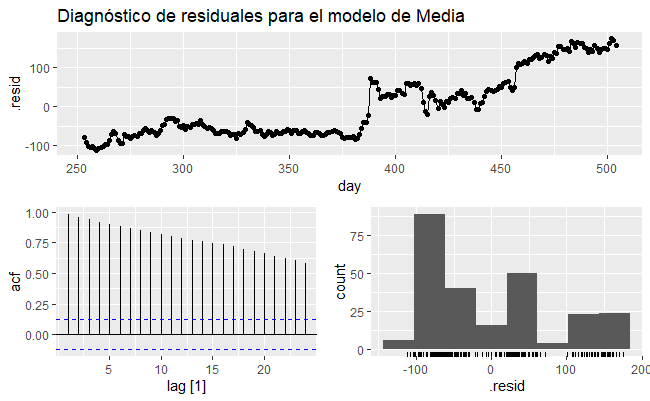

```r
google_2015 %>%
  model(MEAN(Close)) %>%
  gg_tsresiduals() +
  ggtitle("Diagnóstico de residuales para el modelo de Media")
```

Observamos que estas gráficas tienen un comportamiento muy distinto al Naïve:

- En la gráfica de los residuales vemos que se distingue claramente un patrón. De hecho, es el mismo patrón exactamente que siguen los datos originales, restándoles su media.
- La función de autocorrelación tiene un comportamiento típico de una caminata aleatoria. Por lo tanto, las autocorrelaciones son significativas.
- El histograma de los residuos muestra claramente que no se distribuyen de manera normal.